# Final Report

王力为 19020152203156

2018年6月3日

# 研究背景

单细胞RNA-seq数据可以通过单细胞水平上基因表达的分子表征来洞察正常的细胞功能和各种疾病状态。单细胞RNA表达分析（scRNA-seq）正在彻底改变整个生物体科学[1,2]，可以在细胞水平上无偏地识别先前未鉴定过的分子异质性，提供了解剖复杂组织和特定细胞环境组成的手段。

本次实验单细胞测序的基因表达数据，420个细胞是单细胞，共16000个基因。402个非正常实验组CLP，18个正常组，sham。

1，这是一个非常非常非平衡数据+超级高维数据的问题，并且小样本——业界难题

2，有监督，分类问题。分类首先是二分类，其次还潜在为多分类问题

3，同时需要有较强大的生物学背景知识支持

4，目的不仅要成功分类（减轻人工压力），还要可解释，即找到因子变量，可能还要确定分类阈值！

问题背景：引用胡杰老师的method文件夹。单细胞测序是干嘛，会遇到什么问题，有什么好的方法。见最后总结（不仅仅是非平衡）

# 研究背景曾老师介绍

1. 关于单细胞分类的。国内就很火

2.以前的技术没有办法单个细胞，bulk测序，所有细胞都混在一块测，传统测序，认为所有细胞都是一样的

3.但现在技术可以了。关键在于怎么分离细胞，如荧光去挑。或者单个芯片类似于管道之类的。

4.它的意义就在于，每个细胞还是不太一样的，同种细胞也会表现出不一样（如都是T细胞，且即便再细分，也不够细分，还有很多小类）。所以单细胞技术可以看到细胞多样性——如细胞发育（同一个祖宗来的）。也可以由这个多样性进一步更好确定某些显著的基因

但这个是优点也是缺点，我们在数据上就会产生非常难办的特征。下面会说到

实验主角是中性粒细胞。中性粒细胞有很多阶段，如成熟或不成熟（成熟没有分化能力有杀菌能力）。同样是成熟或不成熟的细胞是也不一样的。比如在本次实验里的某种感染后，成熟的都不见了，多出来的是不成熟的，而且还和传统不成熟的不一样——这是为啥？？？我们感兴趣的就是这一部分未成熟细胞，和未感染前传统的未成熟细胞的区别。背后的区别就从基因来分辨

5.数据是小鼠胃溃疡，控制组（sham）和实验组（CLP）是：是否有某种感染。看对照小鼠和实验小鼠的整个机体脾脏的中性粒细胞，而且是未成熟的中性粒细胞（也就是这里的单细胞）的RNA的测序基因表达，在有无刺激下面，会不会有某些基因是显著的不同。

注：这里要注意的点是，是否感染，也就是控制实验组的0和1是确定的。但是，人为筛出来的目前所有的样本细胞的“未成熟的中性粒细胞”，①控制组和实验组的未成熟肯定是不一样的，是我们要二分类的原因。②在实验组402个未成熟的中性粒细胞中，还有可能有些未成熟的来源是不一样的，pattern不一样，因此还有可能要多分类——这个多分类应该由聚类解决（但是K非常难确定。这是日后的事情了）

6.现在是真实数据，后续也可以仿真

7.这种基因表达数据的特点

①非正态性非常强，因为现在是分离的，不再是bulk，所以量非常少，所以肯定不漂亮。

②并且因为太少了，有些测不到，所以造成零膨胀。

③第三个是由于基因数据不纯，虽然都是非成熟细胞，但不同的细胞所在的pattern可能不太一样，所以会存在多峰多模态的特点。

8.所以要用非参模型会更加有效！！！！

9.同时是非平衡的，这个不用说了。可以用真实数据做，也可以用仿真数据做。但在多重假设检验里其实影响不是很大。影响更大的是零膨胀dropout

10.那仿真技术呢，原始的bulk，分位数变换，加上其他方法可以实现

11.有些可以从降维看development，有些是发育的时间来分等（基于流形的方法）（早期分不开，stage接不上，不太好。但晚期分的比较好。找个投影）

后续： 12.多重假设检验会遇到的问题：

①非平衡，n1，n2不同，power会不同

②零膨胀，太多的零会不会对KS（已知不能用正态检验了，那就KS检验吧）造成影响

注，可以用SPLATTER方法，仿真设置missing rate；或ZINB-WAVE，仿真同一个整体不同的missing data，验证KS是否合适。不管怎么样后续再说

13.曾老师那边还用了秩相关检验的方法，是基因与基因之间的，这个还不清楚老师具体是怎么操作的。到时候可以再试一下。

# 目前的两大方向

1.针对非平衡高维二分类数据的各种机器学习方法。以下又细分成shrinkage和树方法等。选出来的基因进行探讨。遇到的问题就是非平衡和高维，还有二分类是否合适，还有就是非常多的随机种子随机因素，对最后结果造成的影响！！！

注：零膨胀和非正态并没有处理，不过AUC值已经比较高了，会不会影响、要不要处理暂时省略

2.使用多重假设检验，遇到的问题就是非正态、非平衡和零膨胀。用KS非参的方法一个个试，0太多的基因直接去掉。

*3.sc3等方法的聚类，多分类问题（这个最后再解决吧，慢慢来）

*4.老师那边的秩相关检验的方法，还不知道怎么实施

# 载入包

```r
library(glmnet)
library(ncvreg)
library(MASS)
#library(bigRR)
library(parallel)
library(caret)
library(pROC)
library(kernlab)
library(ROCR)
```

```r
library(grplasso)

library(Rtsne)
library(rgl)
library(scatterplot3d)

library(adabag)
library(rpart)
library(tree)
library(e1071)
library(randomForest)
library(DMwR)
```

# 导入数据

```r
rawdata<-readRDS("C:\\Users\\Haha\\Desktop\\单细胞测序\\immature_neutrophil.rds")
condition<-rawdata[['condition']]
condition<-data.frame(condition)
data<-data.frame(rawdata[['data']])
data<-data.frame(t(data))
condition<-condition$condition
data<-cbind(condition,data)
data[1:5,1:5]
```

```
##                      condition X0610005C13Rik X0610007P14Rik
## CATGCCTA_ATCA_ACCTGT       CLP              0              0
## CATGCCTA_ATCA_TGTCTT       CLP              0              0
## GCTCAGGA_ATCA_TGTCTT      sham              0              0
## TTCTGCCT_CTAC_CTGGTC       CLP              0              0
## TTCTGCCT_CTAC_TGTTAC       CLP              0              0
##                      X0610009B22Rik X0610009L18Rik
## CATGCCTA_ATCA_ACCTGT              0              0
## CATGCCTA_ATCA_TGTCTT              0              0
## GCTCAGGA_ATCA_TGTCTT              0              0
## TTCTGCCT_CTAC_CTGGTC              0              0
## TTCTGCCT_CTAC_TGTTAC              0              0
```

```r
###########
#Sum<-apply(data[,-1], 1, sum)
#Mean<-apply(data[,-1], 1, mean)
#Std<-apply(data[,-1], 1, sd)
#Median<-apply(data[,-1], 1, median)
#datadiscribe<-cbind(data,Sum,Mean,Std,Median)
#head(datadiscribe[,(ncol(datadiscribe)-3):ncol(datadiscribe)])

#######
#sum(datadiscribe$condition=='sham')
#sum(datadiscribe$condition=='CLP')

#boxplot(Sum~condition,col=c(2:6))
#boxplot(Mean~condition,col=c(2:6))
#boxplot(Std~condition,col=c(2:6))
#看不出什么差别

#plot(Mean,Std,pch=20,col=factor(condition),lty=1,lwd=1)
#红点为sham，对照组（正常的表达），18个，非平衡
#这样子看实在是太太非平衡了

##############缺失值

#hang<-which(rowSums(is.na(data)) > 0)
#hang#没有缺失值！！
```

# 方向一：非平衡高维分类问题方向

## 数据预处理

为防止数据随机性，本文所有种子都设置为1

```r
#################
#准备工作，拆分成训练集和测试集
set.seed(1)
Y<-data$condition
Ytestnum<-c(sample(which(Y=='sham'),length(which(Y=='sham'))/3,replace = F),sample(which(Y=='CLP'),length(which(Y=='CLP'))/3,replace = F))
Ytestnum<-sample(Ytestnum,length(Ytestnum),replace = F)
Ytest<-Y[Ytestnum]#三分之一分给测试集，三分之二为训练集.
Ytrain<-Y[-Ytestnum]
Y01<-rep(1,length(Y))
Y01[Y=='sham']<-0
Ytrain01<-rep(1,length(Ytrain))
Ytrain01[Ytrain=='sham']<-0 #sham的，即正常的，取0，为非常少的部分
Ytest01<-rep(1,length(Ytest))
Ytest01[Ytest=='sham']<-0
length(Ytest01)
```

```
## [1] 140
```

```r
XXX<-as.matrix(data[,2:ncol(data)])
#然后取出一整列都是0的列
XX<-XXX[,-which(apply(abs(XXX),2,sum)==0)]
dim(XX)
```

```
## [1]   420 13503
```

```r
length0<-function(X){
  return(sum(X!=0))#n=402减去0的个数，为非0的个数，如第一列在训练集中，只有8个非0
}
X<-XX[,which(apply(XX[which(Y=='CLP'),],2,length0)>=0.05*402)]#非0元素个数小于20的列,直接删掉
dim(X)
```

```
## [1]  420 6593
```

```r
Xtest<-X[Ytestnum,]
Xtrain<-X[-Ytestnum,]
dim(Xtrain)
```

```
## [1]  280 6593
```

```r
Xscale<-scale(X)
Xtestscale<-Xscale[Ytestnum,]
Xtrainscale<-Xscale[-Ytestnum,]
dim(Xtrainscale)
```

```
## [1]  280 6593
```

三分之一分给测试集，三分之二为训练集，即280:140. 402：18， 测试集的小样本只有6个

### TSNE

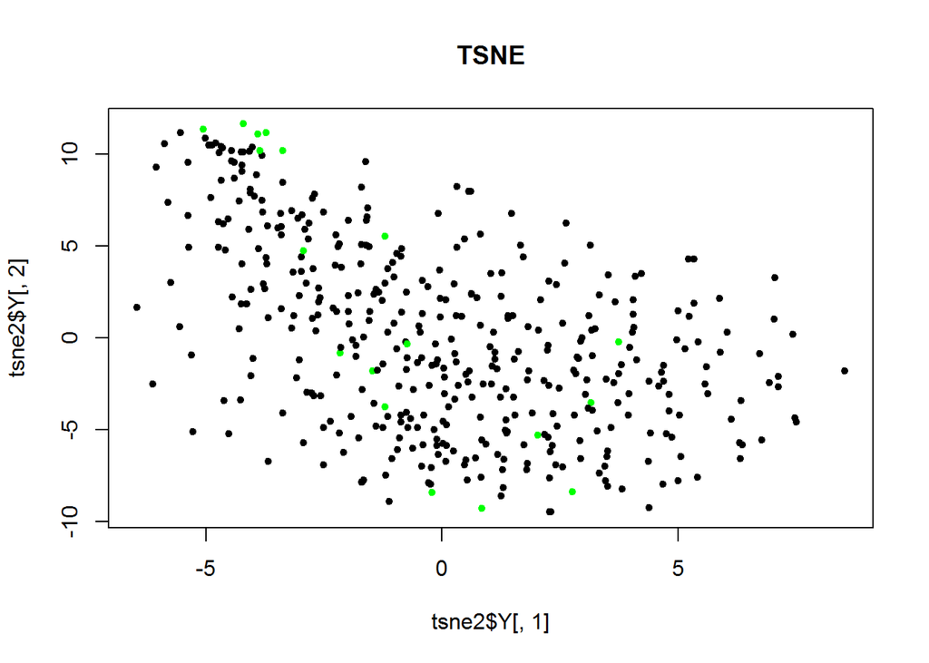

```r
color<-rep('black', length(Y))
color[which(Y=='sham')]<-'green'#绿色是sham！！！！！！！！！！！！

set.seed(1)
tsne2<-Rtsne(X,dims = 2)
plot(tsne2$Y[,1],tsne2$Y[,2],main='TSNE',col=color,pch=20)
```

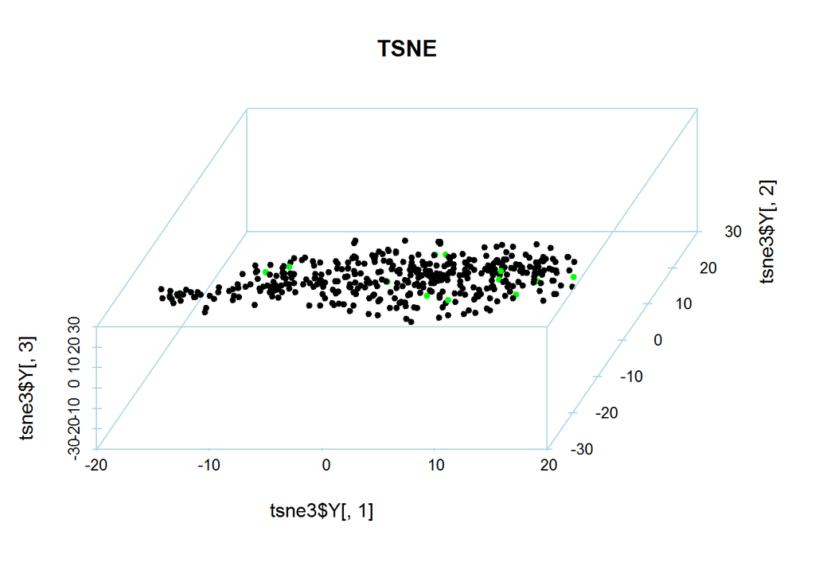

```r
set.seed(1)
tsne3<-Rtsne(X,dims = 3,perplexity = 30,verbose = F,max_iter = 1000)
scatterplot3d(tsne3$Y[,1],tsne3$Y[,2],tsne3$Y[,3],color=color,
              highlight.3d=F,pch = 20,angle=80,main='TSNE',
              type = 'p',grid = F,col.grid = "lightblue",col.axis = 'lightblue',col.lab = T,scale.y =2,xlim = c(-20,20),ylim = c(-25,25),zlim = c(-30,30))
```

并没有多大区别，分的很零散，并不能给出什么建议

## Shrinkage,各种LASSO的思路,解决高维建模问题

（1）不用STEP是因为维度太大，STEP极易陷入局部最优解

（2）不用主成分降维是因为要具体到某一个基因，所以主成分出来的意义不大。当然除非有非常强的生物学解释意义，不排除这种做法。可后续尝试。

### SCAD

```r
#然后scad
set.seed(1)
scad.mod<-cv.ncvreg(Xtrainscale,Ytrain01,family='binomial',penalty='SCAD')
```

```r
#plot(scad.mod)
coeffscad<-coef(scad.mod)

#如果用SCAD的话，提取出不为0的自变量——貌似系数都是负数
sum(coeffscad[-1]!=0)
```

```
## [1] 9
```

```r
sum(coeffscad[-1]==0)
```

```
## [1] 6584
```

```r
sort(abs(coeffscad[which(coeffscad[-1]!=0)+1]),decreasing = T)
```

```
##       Calr       Gzma       Ccl5      Hspa5      Snx19       Eif1
## 0.42192610 0.25076579 0.22140801 0.19086936 0.07581323 0.01446535
##      Axin1      Nt5c3      Hacd4
## 0.01407338 0.01310684 0.00875852
```

```r
class(coeffscad)
```

```
## [1] "numeric"
```

```r
#共有9个，有正有负。最重要的由系数的绝对值大小决定

#Calr        Gzma        Ccl5       Hspa5       Snx19        Eif1
# Axin1      Nt5c3      Hacd4

pred.scad<-predict(scad.mod,Xtrainscale,type='response',family='binomial')
pred.scad2<-prediction(pred.scad,Ytrain01)

#这是已经找到最优阈值的一种简便方法，阈值不再是0.5
#如果要看阈值为0.5的话...基本上都是0

perfscad<-performance(pred.scad2,'sens','spec')
#perfscad@x.values#specificity
#perfscad@y.values#TPR
performance(pred.scad2,'auc')@y.values#0.97
```

```
## [[1]]
## [1] 0.9685945
```

```r
pred.scad<-predict(scad.mod,Xtestscale,type='response',family='binomial')
pred.scad2<-prediction(pred.scad,Ytest01)

#这是已经找到最优阈值的一种简便方法，阈值不再是0.5
#如果要看阈值为0.5的话...基本上都是0

perfscad<-performance(pred.scad2,'sens','spec')
#perfscad@x.values#specificity
#perfscad@y.values#TPR
performance(pred.scad2,'auc')@y.values#0.91
```

```
## [[1]]
## [1] 0.9154229
```

```r
auc.scad<-roc(Ytest01,pred.scad)
print(auc.scad)
```

```
##
## Call:
## roc.default(response = Ytest01, predictor = pred.scad)
##
## Data: pred.scad in 6 controls (Ytest01 0) < 134 cases (Ytest01 1).
## Area under the curve: 0.9154
```

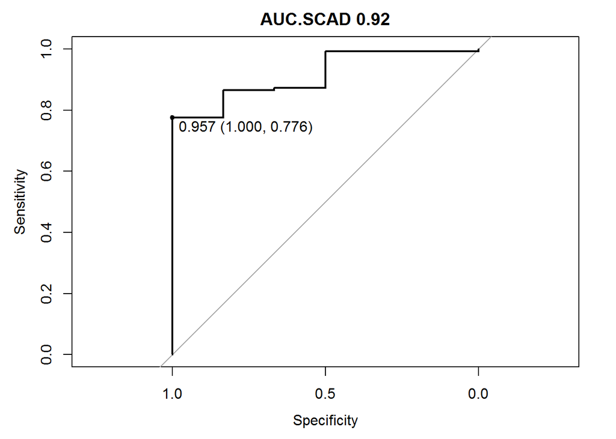

```r
plot(auc.scad,ylim=c(0,1),print.thres=T,main=paste('AUC.SCAD',round(auc.scad$auc[[1]],2)))
```

```r
#阈值为0.957，什么意思？即大于这个值才为1，CLP病变
```

AUC达到0.91,对应的sensitivity（TPR）和specificity（1-FPR）。最优阈值为0.957。都如图。

### ridge+adaptiveLasso

```r
#然后ridge+adaptiveLasso

set.seed(1)
ridge.mod2<-cv.glmnet(Xtrainscale,Ytrain01,alpha=0,family='binomial',type.measure = 'auc')
coeffridge<-coef(ridge.mod2)
w<-1/abs(coeffridge[-1])
adalasso.mod<-cv.glmnet(Xtrainscale,Ytrain01,alpha=1,penalty.factor=w,family='binomial',type.measure = 'auc')
coeffada2<-coef(adalasso.mod)
length(w)
```

```
## [1] 6593
```

```r
sum(coeffada2[-1]!=0)
```

```
## [1] 5
```

```r
which(coeffada2[-1]!=0)
```

```
## [1]  794  879 2338 2520 5295
```

```r
sum(coeffada2[-1]==0)
```

```
## [1] 6588
```

```r
order(abs(coeffada2[coeffada2!=0]),decreasing = T)
```

```
## <sparse>[ <logic> ] : .M.sub.i.logical() maybe inefficient
```

```
## [1] 1 2 5 4 3 6
```

```r
coeffada2@Dimnames[[1]][order(abs(coeffada2[coeffada2!=0]),decreasing = T)]
```

```
## <sparse>[ <logic> ] : .M.sub.i.logical() maybe inefficient
```

```
## [1] "(Intercept)"    "X0610007P14Rik" "X0610010K14Rik" "X0610009O20Rik"
## [5] "X0610009B22Rik" "X0610012G03Rik"
```

```r
class(coeffada2)
```

```
## [1] "dgCMatrix"
## attr(,"package")
## [1] "Matrix"
```

```r
#"X0610009B22Rik" "X0610037L13Rik" "X0610009O20Rik" "X0610012G03Rik"
#"X1110004F10Rik" "X0610030E20Rik" "X0610007P14Rik" "X0610010K14Rik"

#######
#但是没有任何同样出现的基因？
##########

pred.ada<-predict(adalasso.mod,Xtrainscale,type='response',family='binomial')
pred.ada2<-prediction(pred.ada,Ytrain01)
perfada<-performance(pred.ada2,'sens','spec')
#perfada@x.values#specificity
#perfada@y.values#TPR
performance(pred.ada2,'auc')@y.values#0.96
```

```
## [[1]]
## [1] 0.96051
```

```r
pred.ada<-predict(adalasso.mod,Xtestscale,type='response',family='binomial')
pred.ada2<-prediction(pred.ada,Ytest01)
perfada<-performance(pred.ada2,'sens','spec')
#perfada@x.values#specificity
#perfada@y.values#TPR
performance(pred.ada2,'auc')@y.values#0.91
```

```
## [[1]]
## [1] 0.9129353
```

```r
auc.ada<-roc(Ytest01,pred.ada)
print(auc.ada)
```

```
##
## Call:
## roc.default(response = Ytest01, predictor = pred.ada)
##
## Data: pred.ada in 6 controls (Ytest01 0) < 134 cases (Ytest01 1).
## Area under the curve: 0.9129
```

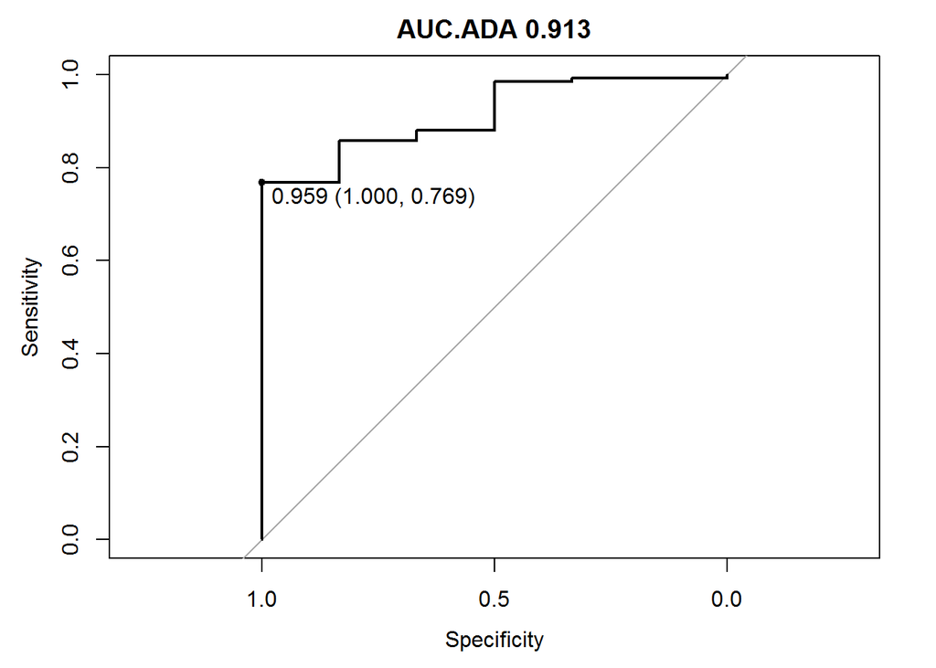

```r
plot(auc.ada,ylim=c(0,1),print.thres=T,main=paste('AUC.ADA',round(auc.ada$auc[[1]],3)))
```

```r
#阈值为0.959
```